# Santander Value Prediction Challenge

In today's modern world, data privacy has become critically important when working with personal information. In the consulting and open source worlds, forms of anonymization and data encryption are being used more frequently to ensure private data is not open to the public. This, however, from a data science viewpoint, makes the analyst process difficult. Therefore, any data scientist needs to be comfortable with working with and drawing meaning from anonymous data.

Notebook structure:

1. Importing the data
2. EDA
3. Feature Engineering
4. Feature Selection
5. Selecting the best model
6. Tuning the model
7. Final results

-/ Written by Leonard Phillips

```python
# Load libraries.
import numpy as np
import pandas as pd
pd.set_option('display.float_format', lambda x: '%.3f' % x)
import scipy
import os
import time
import gc
from pprint import pprint

import matplotlib.pyplot as plt
import seaborn as sns
plt.style.use('ggplot')

from sklearn.neighbors import KNeighborsRegressor
from sklearn.tree import DecisionTreeRegressor
from sklearn.ensemble import RandomForestRegressor
import xgboost as xgb

from sklearn.model_selection import ParameterGrid
from sklearn.model_selection import RandomizedSearchCV
from sklearn.model_selection import GridSearchCV
from sklearn.model_selection import train_test_split
from sklearn.model_selection import KFold
from sklearn import metrics
```

```python
# Import datasets.
path = '../input/santander-value-prediction-challenge/'
train = pd.read_csv(path + 'train.csv')
test = pd.read_csv(path + 'test.csv')
```

#### Memory Reduction

The following function reduces the size of our dataset to reduce the amount of RAM needed.

This function was created by https://www.kaggle.com/rinnqd.

Reference: https://www.kaggle.com/rinnqd/reduce-memory-usage

```python
def reduce_mem_usage(df, verbose=True):
    numerics = ['int16', 'int32', 'int64', 'float16', 'float32', 'float64']
    start_mem = df.memory_usage().sum() / 1024**2
    for col in df.columns:
        col_type = df[col].dtypes
        if col_type in numerics:
            c_min = df[col].min()
            c_max = df[col].max()
            if str(col_type)[:3] == 'int':
                if c_min > np.iinfo(np.int8).min and c_max < np.iinfo(np.int8).max:
                    df[col] = df[col].astype(np.int8)
                elif c_min > np.iinfo(np.int16).min and c_max < np.iinfo(np.int16).max:
                    df[col] = df[col].astype(np.int16)
                elif c_min > np.iinfo(np.int32).min and c_max < np.iinfo(np.int32).max:
                    df[col] = df[col].astype(np.int32)
                elif c_min > np.iinfo(np.int64).min and c_max < np.iinfo(np.int64).max:
                    df[col] = df[col].astype(np.int64)
            else:
                if c_min > np.finfo(np.float16).min and c_max < np.finfo(np.float16).max:
                    df[col] = df[col].astype(np.float16)
                elif c_min > np.finfo(np.float32).min and c_max < np.finfo(np.float32).max:
                    df[col] = df[col].astype(np.float32)
                else:
                    df[col] = df[col].astype(np.float64)

    end_mem = df.memory_usage().sum() / 1024**2
    print('Memory usage after optimization is: {:.2f} MB'.format(end_mem))
    print('Decreased by {:.1f}%'.format(100 * (start_mem - end_mem) / start_mem))

    return df
```

```python
%%time
train = reduce_mem_usage(train)
test = reduce_mem_usage(test)
```

```
Memory usage after optimization is: 81.70 MB
Decreased by 51.9%
Memory usage after optimization is: 939.81 MB
Decreased by 50.0%
CPU times: user 18min 35s, sys: 41min 55s, total: 1h 31s
Wall time: 1h 35s
```

## EDA

First we want to get an idea of what we are working with. Lets have a look at the shape, head, tail and the data types in each row.

```python
print(f'The train dataset has {train.shape[0]} rows and {train.shape[1]} columns')
print(f'The test dataset has {test.shape[0]} rows and {test.shape[1]} columns')
```

```
The train dataset has 4459 rows and 4993 columns
The test dataset has 49342 rows and 4992 columns
```

```python
train.info()
```

```
<class 'pandas.core.frame.DataFrame'>
RangeIndex: 4459 entries, 0 to 4458
Columns: 4993 entries, ID to 9fc776466
dtypes: float32(1845), int16(14), int32(2869), int64(8), int8(256), object(1)
memory usage: 81.7+ MB
```

```python
test.info()
```

```
<class 'pandas.core.frame.DataFrame'>
RangeIndex: 49342 entries, 0 to 49341
Columns: 4992 entries, ID to 9fc776466
dtypes: float32(4991), object(1)
memory usage: 939.8+ MB
```

Just from the initial look, it seems we have a very sparse dataset for both the train and test data. All columns have been anonymised so it will be tricky to get an intuition on what variables we want to use. We also see that there are more features than rows so manual feature selection will not be feasible. The target variable seems to consist of very large values.

The test dataset maybe to large to work and might require memory reducion. This can be determined when building the model.

```python
train.head(5)
```

|  | ID | target | 48df886f9 | 0deb4b6a8 | 34b15f335 | a8cb14b00 | 2f0771a37 | 30347e683 | d08d1fbe3 | 6ee66e115 | ... | 3ecc09859 | 9281abeea | 8675bec0b | 3a13ed79a | f677d4d13 | 71b203550 | 137efaa80 | fb36b89d9 | 7e293fbaf | 9fc776466 |
| --- | --- | --- | --- | --- | --- | --- | --- | --- | --- | --- | --- | --- | --- | --- | --- | --- | --- | --- | --- | --- | --- |
| 0 | 000d6aaf2 | 38000000.000 | 0.000 | 0 | 0.000 | 0 | 0 | 0 | 0 | 0 | ... | 0.000 | 0.000 | 0.000 | 0 | 0 | 0 | 0 | 0 | 0 | 0 |
| 1 | 000fbd867 | 600000.000 | 0.000 | 0 | 0.000 | 0 | 0 | 0 | 0 | 0 | ... | 0.000 | 0.000 | 0.000 | 0 | 0 | 0 | 0 | 0 | 0 | 0 |
| 2 | 0027d6b71 | 10000000.000 | 0.000 | 0 | 0.000 | 0 | 0 | 0 | 0 | 0 | ... | 0.000 | 0.000 | 0.000 | 0 | 0 | 0 | 0 | 0 | 0 | 0 |
| 3 | 0028cbf45 | 2000000.000 | 0.000 | 0 | 0.000 | 0 | 0 | 0 | 0 | 0 | ... | 0.000 | 0.000 | 0.000 | 0 | 0 | 0 | 0 | 0 | 0 | 0 |
| 4 | 002a68644 | 14400000.000 | 0.000 | 0 | 0.000 | 0 | 0 | 0 | 0 | 0 | ... | 0.000 | 0.000 | 0.000 | 0 | 0 | 0 | 0 | 0 | 0 | 0 |

5 rows × 4993 columns

```python
test.head(5)
```

|  | ID | 48df886f9 | 0deb4b6a8 | 34b15f335 | a8cb14b00 | 2f0771a37 | 30347e683 | d08d1fbe3 | 6ee66e115 | 20aa07010 | ... | 3ecc09859 | 9281abeea | 8675bec0b | 3a13ed79a | f677d4d13 | 71b203550 | 137efaa80 | fb36b89d9 | 7e293fbaf | 9fc776466 |
| --- | --- | --- | --- | --- | --- | --- | --- | --- | --- | --- | --- | --- | --- | --- | --- | --- | --- | --- | --- | --- | --- |
| 0 | 000137c73 | 0.000 | 0.000 | 0.000 | 0.000 | 0.000 | 0.000 | 0.000 | 0.000 | 0.000 | ... | 0.000 | 0.000 | 0.000 | 0.000 | 0.000 | 0.000 | 0.000 | 0.000 | 0.000 | 0.000 |
| 1 | 00021489f | 0.000 | 0.000 | 0.000 | 0.000 | 0.000 | 0.000 | 0.000 | 0.000 | 0.000 | ... | 0.000 | 0.000 | 0.000 | 0.000 | 0.000 | 0.000 | 0.000 | 0.000 | 0.000 | 0.000 |
| 2 | 0004d7953 | 0.000 | 0.000 | 0.000 | 0.000 | 0.000 | 0.000 | 0.000 | 0.000 | 0.000 | ... | 0.000 | 0.000 | 0.000 | 0.000 | 0.000 | 0.000 | 0.000 | 0.000 | 0.000 | 0.000 |
| 3 | 00056a333 | 0.000 | 0.000 | 0.000 | 0.000 | 0.000 | 0.000 | 0.000 | 0.000 | 0.000 | ... | 0.000 | 0.000 | 0.000 | 0.000 | 0.000 | 0.000 | 0.000 | 0.000 | 0.000 | 0.000 |
| 4 | 00056d8eb | 0.000 | 0.000 | 0.000 | 0.000 | 0.000 | 0.000 | 0.000 | 0.000 | 0.000 | ... | 0.000 | 0.000 | 0.000 | 0.000 | 0.000 | 0.000 | 0.000 | 0.000 | 0.000 | 0.000 |

5 rows × 4992 columns

```python
train.describe()
```

|  | target | 48df886f9 | 0deb4b6a8 | 34b15f335 | a8cb14b00 | 2f0771a37 | 30347e683 | d08d1fbe3 | 6ee66e115 | 20aa07010 | ... | 3ecc09859 | 9281abeea | 8675bec0b | 3a13ed79a | f677d4d13 | 71b203550 | 137efaa80 | fb36b89d9 | 7e293fbaf | 9fc776466 |
| --- | --- | --- | --- | --- | --- | --- | --- | --- | --- | --- | --- | --- | --- | --- | --- | --- | --- | --- | --- | --- | --- |
| count | 4459.000 | 4459.000 | 4459.000 | 4459.000 | 4459.000 | 4459.000 | 4459.000 | 4459.000 | 4459.000 | 4459.000 | ... | 4459.000 | 4459.000 | 4459.000 | 4459.000 | 4459.000 | 4459.000 | 4459.000 | 4459.000 | 4459.000 | 4459.000 |
| mean | 5944940.500 | 14654.930 | 1390.895 | 26722.451 | 4530.164 | 26409.957 | 30708.106 | 16865.216 | 4669.208 | 2569405.500 | ... | 467605.688 | 444623.875 | 805621.625 | 781296.636 | 143.530 | 121380.933 | 35734.514 | 312374.075 | 92199.596 | 227909.956 |
| std | 8234321.000 | 389316.281 | 64283.024 | 569976.250 | 235912.407 | 1514730.151 | 577058.975 | 751275.594 | 187944.888 | 9610130.000 | ... | 4068025.500 | 4428877.000 | 4513256.500 | 6839450.755 | 9584.319 | 4720708.533 | 1614622.198 | 4318500.708 | 1635993.425 | 1811139.277 |
| min | 30000.000 | 0.000 | 0.000 | 0.000 | 0.000 | 0.000 | 0.000 | 0.000 | 0.000 | 0.000 | ... | 0.000 | 0.000 | 0.000 | 0.000 | 0.000 | 0.000 | 0.000 | 0.000 | 0.000 | 0.000 |
| 25% | 600000.000 | 0.000 | 0.000 | 0.000 | 0.000 | 0.000 | 0.000 | 0.000 | 0.000 | 0.000 | ... | 0.000 | 0.000 | 0.000 | 0.000 | 0.000 | 0.000 | 0.000 | 0.000 | 0.000 | 0.000 |
| 50% | 2260000.000 | 0.000 | 0.000 | 0.000 | 0.000 | 0.000 | 0.000 | 0.000 | 0.000 | 0.000 | ... | 0.000 | 0.000 | 0.000 | 0.000 | 0.000 | 0.000 | 0.000 | 0.000 | 0.000 | 0.000 |
| 75% | 8000000.000 | 0.000 | 0.000 | 0.000 | 0.000 | 0.000 | 0.000 | 0.000 | 0.000 | 600000.000 | ... | 0.000 | 0.000 | 0.000 | 0.000 | 0.000 | 0.000 | 0.000 | 0.000 | 0.000 | 0.000 |
| max | 40000000.000 | 20000000.000 | 4000000.000 | 20000000.000 | 14800000.000 | 100000000.000 | 20708000.000 | 40000000.000 | 10400000.000 | 319612000.000 | ... | 76000000.000 | 123588000.000 | 130000000.000 | 144400000.000 | 640000.000 | 301312000.000 | 106420000.000 | 140000000.000 | 61768000.000 | 43200000.000 |

8 rows × 4992 columns

A quick look at the data statistics reveals just how sparse the data is. All features in this matrix have a minimum value of 0 with most having maximum values in the millions. Due to these zero values, we are not getting a true representation of the data statistics. The following script replaces the zeros with NaN values and runs the same describe method.

```python
train_no_zero = train.replace([0, 0.0], np.NAN)
train_no_zero.describe()
```

|  | target | 48df886f9 | 0deb4b6a8 | 34b15f335 | a8cb14b00 | 2f0771a37 | 30347e683 | d08d1fbe3 | 6ee66e115 | 20aa07010 | ... | 3ecc09859 | 9281abeea | 8675bec0b | 3a13ed79a | f677d4d13 | 71b203550 | 137efaa80 | fb36b89d9 | 7e293fbaf | 9fc776466 |
| --- | --- | --- | --- | --- | --- | --- | --- | --- | --- | --- | --- | --- | --- | --- | --- | --- | --- | --- | --- | --- | --- |
| count | 4459.000 | 39.000 | 4.000 | 33.000 | 2.000 | 5.000 | 47.000 | 5.000 | 5.000 | 1494.000 | ... | 291.000 | 185.000 | 693.000 | 165.000 | 1.000 | 35.000 | 18.000 | 34.000 | 80.000 | 163.000 |
| mean | 5944940.500 | 1675547.000 | 1550500.000 | 3610770.000 | 10100000.000 | 23552400.000 | 2913349.872 | 15040400.000 | 4164000.000 | 7668660.500 | ... | 7165133.000 | 10716637.000 | 5183646.000 | 21113949.697 | 640000.000 | 15463930.914 | 8852233.333 | 40966941.176 | 5138975.000 | 6234665.607 |
| std | 8234321.000 | 3863460.000 | 1714083.915 | 5649028.000 | 6646803.743 | 43179858.416 | 4867344.886 | 18616943.165 | 4209332.489 | 15383016.000 | ... | 14361149.000 | 19093432.000 | 10416169.000 | 28976628.398 | nan | 51746827.797 | 24515547.162 | 28344455.937 | 11170090.633 | 7251597.015 |
| min | 30000.000 | 28000.000 | 6000.000 | 30000.000 | 5400000.000 | 54000.000 | 144000.000 | 6000.000 | 600000.000 | 2000.000 | ... | 2000.000 | 8000.000 | 2000.000 | 2208.000 | 640000.000 | 50000.000 | 40000.000 | 170000.000 | 20000.000 | 5348.000 |
| 25% | 600000.000 | 115000.000 | 751500.000 | 120000.000 | 7750000.000 | 148000.000 | 500000.000 | 1196000.000 | 1220000.000 | 583250.000 | ... | 235000.000 | 400000.000 | 600000.000 | 1100000.000 | 640000.000 | 300000.000 | 840550.000 | 20000000.000 | 600000.000 | 400000.000 |
| 50% | 2260000.000 | 280000.000 | 1098000.000 | 1070000.000 | 10100000.000 | 2560000.000 | 840000.000 | 4000000.000 | 2000000.000 | 2200000.000 | ... | 1674000.000 | 2043000.000 | 2134666.750 | 6982400.000 | 640000.000 | 1116000.000 | 3420000.000 | 50000000.000 | 3000000.000 | 2800000.000 |
| 75% | 8000000.000 | 650000.000 | 1897000.000 | 5000000.000 | 12450000.000 | 15000000.000 | 1630000.000 | 30000000.000 | 6600000.000 | 8000000.000 | ... | 10000000.000 | 12800000.000 | 4840000.000 | 40770000.000 | 640000.000 | 8550000.000 | 3420000.000 | 50000000.000 | 3000000.000 | 12152500.000 |
| max | 40000000.000 | 20000000.000 | 4000000.000 | 20000000.000 | 14800000.000 | 100000000.000 | 20708000.000 | 40000000.000 | 10400000.000 | 319612000.000 | ... | 76000000.000 | 123588000.000 | 130000000.000 | 144400000.000 | 640000.000 | 301312000.000 | 106420000.000 | 140000000.000 | 61768000.000 | 43200000.000 |

8 rows × 4992 columns

With the zero values removed, we can see just how spread the data is. The standard deviations of most features are extremely large. I suspect highly skewed features.

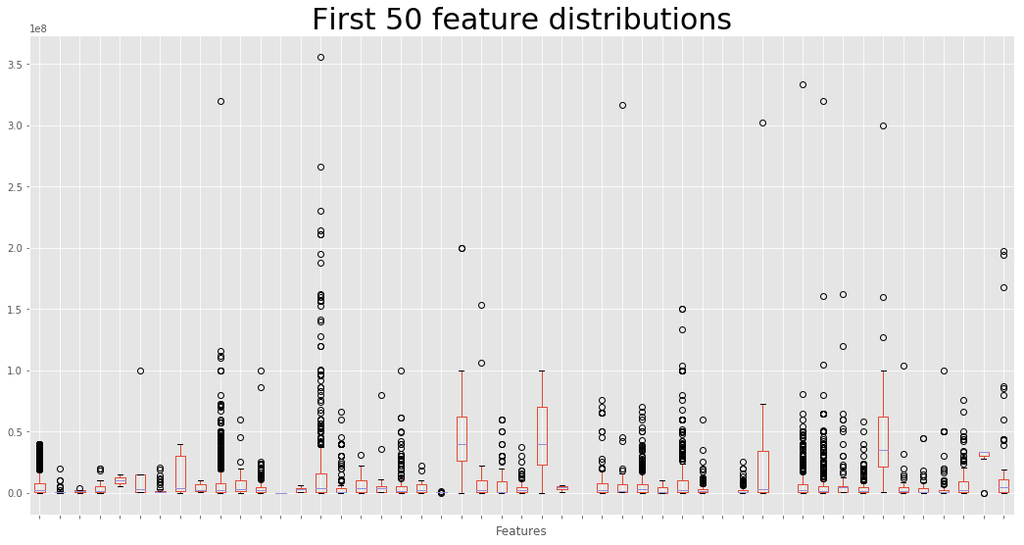

```python
num_cols = train_no_zero.iloc[:, :50].columns
fig,ax = plt.subplots(1)
fig.set_size_inches(18, 9)

train_no_zero[num_cols].boxplot()
ax.set_xticklabels([])
plt.xlabel('Features')
plt.title('First 50 feature distributions', Fontsize=30)
plt.show()
```

A visual examination of the graph above reveals a large number of features have extremely large outliers causing skew. I would recommend a testing whether a log transformation would produce better results. We can also see, now that the zero values have been removed, some features don't have any non-zero values at all. These features will have to be removed before training as they are useless features.

### Missing Values

```python
y_na = train['target'].isna().any().sum()
X_na = train.isna().any().sum()
test_na = test.isna().any().sum()
print(f'{y_na} contain missing values in the target data')
print(f'{X_na} out of {len(train.columns)} columns contain missing values in the predictor data')
print(f'{test_na} out of {len(test.columns)} columns contain missing values in the test data')
```

```
0 contain missing values in the target data
0 out of 4993 columns contain missing values in the predictor data
0 out of 4992 columns contain missing values in the test data
```

From this, we can conclude there is not missing values meaning not data imputation will be needed.

Next, we will explore the features more in-depth.

### Target

```python
print(f'Target minimum & maximum values: {np.min(train["target"])} & {np.max(train["target"])}')
```

```
Target minimum & maximum values: 30000.0 & 40000000.0
```

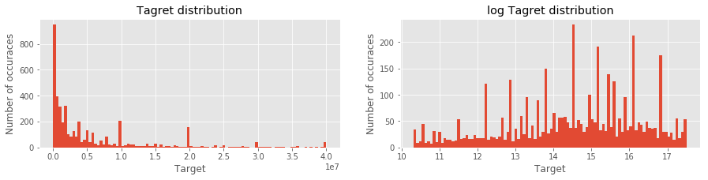

```python
# 'TransactionAmt' feature
fig, (ax1, ax2) = plt.subplots(1, 2, figsize=(15, 3))

# No log
ax1.title.set_text('Tagret distribution')
ax1.set_xlabel('Target')
ax1.set_ylabel('Number of occuraces')
_ = ax1.hist(train['target'], bins=100)

# Log
ax2.title.set_text('log Tagret distribution')
ax2.set_xlabel('Target')
ax2.set_ylabel('Number of occuraces')
_ = ax2.hist(np.log(train['target']), bins=100)
```

After a log transformation, we see a flat distribution occuring with larget peaks between 12 and 17.

### Target/feature correlation

To get some idea of what features might contribute to predicting the target value, calculating the correlation between the target and all features will give us this insight.

```python
%%time
target_corr = train[train.columns[1:]].corr()['target'][:].drop('target').dropna().sort_values()
target_corr_no_zero = train_no_zero[train_no_zero.columns[1:]].corr()['target'][:].drop('target').dropna().sort_values()
```

```
CPU times: user 5min 35s, sys: 92 ms, total: 5min 35s
Wall time: 5min 36s
```

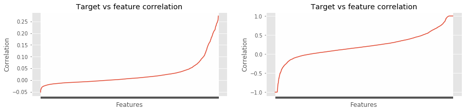

```python
fig, (ax1, ax2) = plt.subplots(1, 2, figsize=(15, 3))

# Normal data
ax1.title.set_text('Target vs feature correlation')
ax1.set_xlabel('Features')
ax1.set_ylabel('Correlation')
ax1.set_xticklabels([])
_ = ax1.plot(target_corr)

# NaN's removed
ax2.title.set_text('Target vs feature correlation')
ax2.set_xlabel('Features')
ax2.set_ylabel('Correlation')
ax2.set_xticklabels([])
_ = ax2.plot(target_corr_no_zero)
```

```python
target_corr_no_zero_df = target_corr_no_zero.to_frame('corr')
target_corr_no_zero_df = target_corr_no_zero_df.where(
    (target_corr_no_zero_df['corr'] > 0.75) | (target_corr_no_zero_df['corr'] < -0.75)
).dropna()

print(f'There are {len(target_corr_no_zero_df.index)} features with high correlation')

del target_corr, target_corr_no_zero
gc.collect()
```

```
There are 385 features with high correlation
```

```
0
```

We can see from the graphs above there are a large number of features that are highly correlated to the target. The features that are 75% correlated should be isolated and trained separately to see whether they improve the model.

## Feature Engineering

We also want to remove any useless features. Features that are constant do not offer anything to the model.

```python
# Removes features containing constant values
y = train['target'].copy()
train = train.drop(['target','ID'], axis=1)

feat_to_remove = []
for feat in train.columns:
    if len(train[feat].unique()) == 1:
        feat_to_remove.append(feat)

train.drop(feat_to_remove, axis=1, inplace=True)

test.drop(feat_to_remove, axis=1, inplace=True)

print(f'Removed {len(feat_to_remove)} Constant Columns\n')
```

```
Removed 256 Constant Columns
```

#### Mean Smoothing

As we do not know the nature of the data due to its anonymity, mean smoothing may not be a meaningful method of adding value to the model. However, this data could be over a certain period. I have decided to smooth along the x-axis over a 3, 6, 12, 7 and 30 bin period to represent 3 months, 6 months, 12 months, 7 days and 30 day period. See Building the Model section below to see results.

```python
## 3 month period
train_3_period_smooth = train.rolling(3,axis=1).mean()

## 6 month period
train_6_period_smooth = train.rolling(6,axis=1).mean()

## 12 month period
train_12_period_smooth = train.rolling(12,axis=1).mean()


## 7-day period
train_7_period_smooth = train.rolling(7,axis=1).mean()

## 30-day period
train_30_period_smooth = train.rolling(30,axis=1).mean()
```

#### Truncation

Due to the sparsity of this data, I believe it could be over a certain period. We explored mean smoothing above, however, what if this data is a month by month or week by week structure. Below I have binned the data along the x-axis in groups of 3, 6, 12, 7 and 30 to represent 3 months, 6 months, 12 months, 7 days and 30 day period. See Building the Model section down below for results.

```python
def Truncate(df, period):
    i = period
    trunc_train = pd.DataFrame()
    while i < len(df.columns):
        col_name =  str(i + 1 - period) + ' - ' + str(i)
        trunc_train[col_name] = df.iloc[:, i-period:i].sum(axis=1)
        i += period

    col_name =  str(i + 1 - period) + ' - ' + str(len(df.columns))
    trunc_train[col_name] = df.iloc[:, i-period:len(df.columns)].sum(axis=1)

    return trunc_train
```

```python
## 3 month period
train_3_period_sum = Truncate(train, 3)
## 6 month period
train_6_period_sum = Truncate(train, 6)
## 12 month period
train_12_period_sum = Truncate(train, 12)

## 7 day period
train_7_period_sum = Truncate(train, 7)
## 30 day period
train_30_period_sum = Truncate(train, 30)
```

## Feature Selection

Before we can do any sort of analysis, we need to separate your target from our features. We also want to log transform our target to acquire a normal distribution.

```python
## Preparing training data
X = train
y = np.log1p(y)

# Preparing non-zero training data
X_corr = train[target_corr_no_zero_df.index]
y_corr = np.log1p(y)

## Preparing log(feature) training data
X_log = np.log1p(train)
y_log = np.log1p(y)

## Preparing mean smoothing training data
X_3mms = train_3_period_smooth
y_3mms = np.log1p(y)
X_6mms = train_6_period_smooth
y_6mms = np.log1p(y)
X_12mms = train_12_period_smooth
y_12mms = np.log1p(y)

X_7dms = train_7_period_smooth
y_7dms = np.log1p(y)
X_30dms = train_30_period_smooth
y_30dms = np.log1p(y)

## Preparing sum truncation training data
X_3m_sum = train_3_period_sum
y_3m_sum = np.log1p(y)
X_6m_sum = train_6_period_sum
y_6m_sum = np.log1p(y)
X_12m_sum = train_12_period_sum
y_12m_sum = np.log1p(y)

X_7d_sum = train_7_period_sum
y_7d_sum = np.log1p(y)
X_30d_sum = train_30_period_sum
y_30d_sum = np.log1p(y)

## Preparing test data
test = test.drop(["ID"], axis=1)


del train, train_no_zero, train_3_period_smooth, train_6_period_smooth, train_12_period_smooth, train_7_period_smooth,
train_30_period_smooth, train_3_period_sum, train_6_period_sum, train_12_period_sum, train_7_period_sum,
train_30_period_sum
gc.collect()
```

```
0
```

# Selecting the best model

Now that our data is ready for analysis, we need to select which model is going to fit the data best. There are four algorithms that we will consider for this problem:

1. KNN Regressor
2. Decision Tree Regressor
3. Random forest
4. XGB

```python
X_train, X_test, y_train, y_test = train_test_split(
    X, y, test_size=0.25, random_state=42)

model_scores = {}
```

### KNN Regressor

```python
kNNRegres = KNeighborsRegressor(n_jobs=-1).fit(X_train, y_train)
model_scores['kNN'] = metrics.mean_squared_error(y_test, kNNRegres.predict(X_test))
```

### Decision Tree Regressor

```python
dTreeRegres = DecisionTreeRegressor(random_state=42).fit(X_train, y_train)
model_scores['Decision Tree'] = metrics.mean_squared_error(y_test, dTreeRegres.predict(X_test))
```

### Random Forest Regressor

```python
randForestRegres = RandomForestRegressor(random_state=42, n_jobs=-1).fit(X, y)
model_scores['Random Forest'] = metrics.mean_squared_error(y_test, randForestRegres.predict(X_test))
```

### XGBoost

```python
xgbRegres = xgb.XGBRegressor(random_state=42, n_jobs=-1).fit(X_train, y_train)
model_scores['XGBoost'] = metrics.mean_squared_error(y_test, xgbRegres.predict(X_test))
```

```
[04:54:57] WARNING: /workspace/src/objective/regression_obj.cu:152: reg:linear is now deprecated in favor of reg:squarederror.
```

### Plotting the results

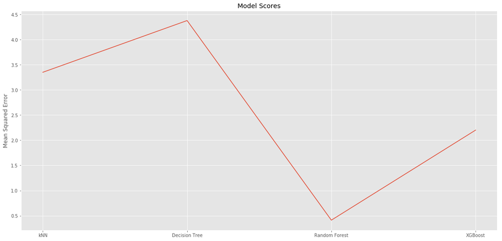

```
2149
```

```python
model_scores_df = pd.DataFrame(model_scores.values(), columns=['scores'], index=model_scores.keys())
plt.figure(figsize=[19,9])
plt.title('Model Scores')
plt.ylabel('Mean Squared Error')
plt.plot(model_scores_df)
plt.show()

gc.collect()
```

# Building the models

## XGBoost: GridSearch with Cross-Validation

To get the best XGB model possible, it is important to try a range of different parameters over the training data. Below is a grid search function that searches every combination between the three parameters provided to it, recording which is the best combination. The metric used for determining the best model is the RMSE.

```python
def search_space(dic, cv):
    combinations = 1
    for values in dic.values():
        combinations *= len(values)
    combinations *= cv
    print(f'Number of combinations: {combinations}')
    print(f'With {cv} number of folds\n')
```

```python
def to_dMatrix(X, y=None):
    if y is None:
        return xgb.DMatrix(X)
    else:
        return xgb.DMatrix(X, y)
```

```python
def create_eval_set(X_val, y_val):
    return [(xgb.DMatrix(X_val, y_val), 'eval')]
```

```python
def GridSearch(hyperParams, train_df, target):
    # GridSearch function can only support the exploration of 3 params in hyperParams

    best_score = np.inf
    best_params = None

    n_folds = 3
    folds = KFold(n_splits=n_folds, shuffle=True, random_state=42)

    const_params = {
        'objective': 'reg:squarederror',
        'eta':0.01,
        'eval_metric':'rmse',
        'tree_method': 'gpu_hist'
    }

#     Create iterable parameters
    grid = ParameterGrid(hyperParams)
    for hyper_params in grid:

#         Create dictionary of params
        param1, param2, param3 = hyper_params.items()
        current_params = {param1[0]: param1[1], param2[0]: param2[1], param3[0]: param3[1]}

#         print('##########################################################################\n')
#         print(f'Parameters being tested: {current_params}')

#         Append param dictionary to model parameters
        const_params.update(current_params)

        kfold_gs_score = 0
        for train_index, test_index in folds.split(train_df):
#             Seperate train/test data
            train_X, train_y = train_df.loc[train_index], target[train_index]
            test_X, test_y = train_df.loc[test_index], target[test_index]

#             Preparing the training data
            eval_set_list = create_eval_set(test_X, test_y)
            dMatTrain = to_dMatrix(train_X, train_y)
            dMatTest = to_dMatrix(test_X)

#             Training the model
            start = time.time()
            gs = xgb.train(
                            params=const_params,
                            dtrain=dMatTrain,
                            num_boost_round=5000,
                            evals=eval_set_list,
                            early_stopping_rounds=100,
                            verbose_eval=False
                            )
            end = time.time()
#             print(f'Execution time: {np.round((end - start),2)}s\n')
#             print('------------------------------------')

            pred_y = np.expm1(gs.predict(dMatTest))

#             Sum kfold model score
            kfold_gs_score += np.sqrt(metrics.mean_squared_error(np.expm1(test_y), pred_y))

#         Produce average model score
        gs_score = kfold_gs_score / n_folds
#         print(f'Parameter score: {gs_score}\n')

#         Only keep the best parameters
        if best_score > gs_score:
            best_score = gs_score
            best_params = current_params
    print(f'The best parameters found were: {best_params}')
    return best_params
```

```python
%%time
grid_params = {
    'subsample': np.arange(0.5,1,0.1).tolist(),
    'max_depth': np.arange(3,12,1).tolist(),
    'min_child_weight': np.arange(3,6,1).tolist()
}
search_space(grid_params, 3)
pprint(grid_params)

best_params = GridSearch(grid_params, X, y)
```

[output not shown]

## Random Forest Regressor: Parameter Tuning with Cross-Validation

As we have done with the XGBoost algorithm, parameter tuning will find the best combination of parameters to get the model out of our model.

```python
k_folds = 3

max_depth = [int(x) for x in np.linspace(2,12,5)]
max_depth.append(None)
random_grid = {
    'n_estimators': [int(x) for x in np.linspace(200,2000,5)],
    'max_depth': max_depth,
    'min_samples_split': [2, 5, 10]
}

search_space(random_grid, k_folds)
pprint(random_grid)
```

```
Number of combinations: 270
With 3 number of folds

{'max_depth': [2, 4, 7, 9, 12, None],
 'min_samples_split': [2, 5, 10],
 'n_estimators': [200, 650, 1100, 1550, 2000]}
```

```python
randForestRegres = RandomForestRegressor(random_state=42)

rs = RandomizedSearchCV(
    estimator=randForestRegres,
    param_distributions=random_grid,
    cv=k_folds
)
rs.fit(X, y)

print(rs.best_params_)
```

```
{'n_estimators': 650, 'min_samples_split': 5, 'max_depth': None}
```

As RandomSearch does not have the best accuracy, we will further tune the parameters using a GridSearch with widened parameter boundaries.

```python
# best_rand_param = {'n_estimators': 650, 'min_samples_split': 5, 'max_depth': None}

grid_params = {
    'n_estimators': [550,650,750],
    'max_depth': [None,1,2],
    'min_samples_split': [4,5,6]
}

search_space(grid_params, k_folds)
pprint(grid_params)
```

```
Number of combinations: 81
With 3 number of folds

{'max_depth': [None, 1, 2],
 'min_samples_split': [4, 5, 6],
 'n_estimators': [550, 650, 750]}
```

```python
# Create a based model
randForestRegres = RandomForestRegressor(random_state=42)

gs = GridSearchCV(
    estimator=randForestRegres,
    param_grid=grid_params,
    cv = k_folds
)
gs.fit(X,y)
print(gs.best_params_)
```

```
{'max_depth': None, 'min_samples_split': 5, 'n_estimators': 750}
```

## Model comparison with optimal parameters

```python
model_scores = {}

randForestRegres = RandomForestRegressor(
    n_estimators=750,
    max_depth=None,
    min_samples_split=5,
    random_state=42,
    n_jobs=-1
).fit(X_train, y_train)
model_scores['Random Forest'] = metrics.mean_squared_error(y_test, randForestRegres.predict(X_test))
```

```python
xgbRegres = xgb.XGBRegressor(
    max_depth=6,
    min_child_weight=4,
    subsample=0.8999999999999999,
    random_state=42,
    n_jobs=-1
).fit(X_train, y_train)
model_scores['XGBoost'] = metrics.mean_squared_error(y_test, xgbRegres.predict(X_test))
```

```
[08:57:12] WARNING: /workspace/src/objective/regression_obj.cu:152: reg:linear is now deprecated in favor of reg:squarederror.
```

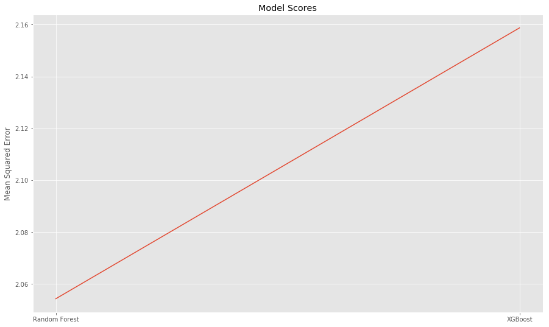

```
1813
```

```python
model_scores_df = pd.DataFrame(model_scores.values(), columns=['scores'], index=model_scores.keys())
plt.figure(figsize=[15,9])
plt.title('Model Scores')
plt.ylabel('Mean Squared Error')
plt.plot(model_scores_df)
plt.show()

gc.collect()
```

From the above graph we can see that the Random Forest regressor offers a better predictability.

# Feature Testing using XGBoost

## Correlated

Now that we have the best parameters for our XGB model, we can measure how well the model preforms with highly correlated features.

I have decided to use the XGBoost algorithm for feature testing because of the increased speed the GPU capablility offers.

```python
def XGBCV(X_data, y_data, model_params, folds_n):
    folds = KFold(n_splits=folds_n, shuffle=True, random_state=42)
    kfold_gs_score=0
    for train_index, test_index in folds.split(X_data):
    #    Seperate train/test data
        train_X, train_y = X_data.loc[train_index], y_data[train_index]
        test_X, test_y = X_data.loc[test_index], y_data[test_index]

    #    Preparing the training data
        eval_set_list = create_eval_set(test_X, test_y)
        dMatTrain = to_dMatrix(train_X, train_y)
        dMatTest = to_dMatrix(test_X)

    #    Training the model
        gs = xgb.train(
                        params=model_params,
                        dtrain=dMatTrain,
                        num_boost_round=5000,
                        evals=eval_set_list,
                        early_stopping_rounds=100,
                        verbose_eval=False
                        )

        pred_y = np.expm1(gs.predict(dMatTest))

    #    Sum kfold model score
        kfold_gs_score += np.sqrt(metrics.mean_squared_error(np.expm1(test_y), pred_y))

    # Produce average model score
    gs_score = kfold_gs_score / folds_n
    return gs_score
```

```python
## Preparing the data
best_params = {'max_depth': 6, 'min_child_weight': 4, 'subsample': 0.8999999999999999}
params = {
    'objective': 'reg:squarederror',
    'eta':0.01,
    'eval_metric':'rmse',
    'tree_method': 'gpu_hist'
}
params.update(best_params)
```

```python
# A collection of all model scores
scores = {}
idx = []
```

```python
# Highly correlated features
scores['corr'] = XGBCV(X_corr, y_corr, params, 5)

del X_corr, y_corr
gc.collect()
```

```
129
```

## Log tranform

Here we will be comparing how well the log transformed model preforms.

```python
# Highly correlated features
scores['log'] = XGBCV(X_log, y_log, params, 5)

del X_log, y_log
gc.collect()
```

```
174
```

Tranformed data did not preform as well as non-transformed data.

## Mean Smoothing

```python
# Mean smoothing features
scores['ms3'] = XGBCV(X_3mms, y_3mms, params, 5)
scores['ms6'] = XGBCV(X_6mms, y_6mms, params, 5)
scores['ms12'] = XGBCV(X_12mms, y_12mms, params, 5)

scores['ms7'] = XGBCV(X_7dms, y_7dms, params, 5)
scores['ms30'] = XGBCV(X_30dms, y_30dms, params, 5)

del X_3mms, X_6mms, X_7dms, y_3mms, y_6mms, y_7dms
gc.collect()
```

[output not shown]

```
266
```

## Period summation

```python
# Period summed features
scores['sum3'] = XGBCV(X_3m_sum, y_3m_sum, params, 5)
scores['sum6'] = XGBCV(X_6m_sum, y_6m_sum, params, 5)
scores['sum12'] = XGBCV(X_12m_sum, y_12m_sum, params, 5)

scores['sum7'] = XGBCV(X_7d_sum, y_7d_sum, params, 5)
scores['sum30'] = XGBCV(X_30d_sum, y_30d_sum, params, 5)

del X_3m_sum, X_6m_sum, X_12m_sum, X_7d_sum, X_30d_sum, y_3m_sum, y_6m_sum, y_12m_sum, y_7d_sum, y_30d_sum
gc.collect()
```

[output not shown]

```
572
```

### Feature Engineering Results

The following graph plots the scores each algorithm achieved.

```python
scores_df = pd.DataFrame(scores.values(), columns=['scores'], index=scores.keys())
```

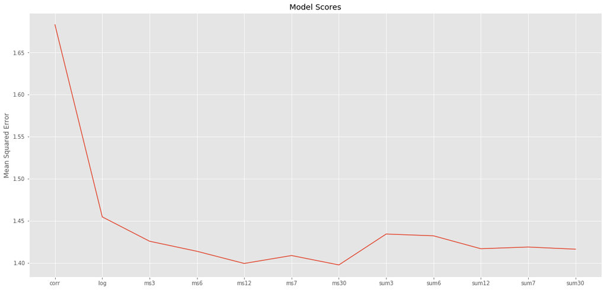

```python
plt.figure(figsize=[19,9])
plt.title('Model Scores')
plt.ylabel('Mean Squared Error')
plt.plot(scores_df)
plt.show()
```

A visual examination of the graph shows MS12 and MS30 as being the best set of parameters.

# Final Model

Now that we have found our best parameters and selected which features to include, we can train our final model and submit to the competition. We will try both random forest and XGBoost with best parameters and optimal features as both algorithms have a good predictive score for this problem.

### Random Forest

```python
randForestRegres = RandomForestRegressor(
    n_estimators=750,
    max_depth=None,
    min_samples_split=5,
    random_state=42,
    n_jobs=-1
)
```

```python
# All features
randForestRegres.fit(X, y)
rf_y_pred = np.expm1(randForestRegres.predict(test))
```

```python
# Mean smoothing 12 month period
X_12mms.fillna(-999, inplace=True)

randForestRegres.fit(X_12mms, y_12mms)
rf_12_y_pred = np.expm1(randForestRegres.predict(test))
```

```python
# Mean smoothing 30 day period
X_30dms.fillna(-999, inplace=True)

randForestRegres.fit(X_30dms, y_30dms)
rf_30_y_pred = np.expm1(randForestRegres.predict(test))
```

### XGBoost

```python
## Data preparation
X_train, X_test, y_train, y_test = train_test_split(
    X_12mms, y_12mms, test_size=0.25, random_state=42)

# Eval_set train/test preformance data
dX_train = xgb.DMatrix(X_train, y_train)
dy_test = xgb.DMatrix(X_test, y_test)

# Training data
dtrain = xgb.DMatrix(X, y)
# Training 12 month mean smoothing data
d12train = xgb.DMatrix(X_12mms, y_12mms)
# Training 30 day mean smoothing data
d30train = xgb.DMatrix(X_30dms, y_30dms)

del X_train, X_test, y_train, y_test, X, y, X_12mms, X_30dms, y_12mms, y_30dms
gc.collect()
```

```
2578
```

```python
dtest = xgb.DMatrix(test)
del test
```

```python
# original algorithm
best_params = {'max_depth': 6, 'min_child_weight': 4, 'subsample': 0.8999999999999999}
params = {
    'objective': 'reg:squarederror',
    'eta':0.01,
    'eval_metric':'rmse',
    'tree_method': 'gpu_hist'
}

params.update(best_params)

eval_set = [(dX_train, 'train'), (dy_test, 'eval')]
```

```python
bst = xgb.train(
                params=params,
                dtrain=dtrain,
                num_boost_round=5000,
                evals=eval_set,
                early_stopping_rounds=100,
                verbose_eval=False
                )
xgb_y_pred = np.expm1(bst.predict(dtest))

del dtrain
```

```python
bst = xgb.train(
                params=params,
                dtrain=d12train,
                num_boost_round=5000,
                evals=eval_set,
                early_stopping_rounds=100,
                verbose_eval=False
                )
xgb_12_y_pred = np.expm1(bst.predict(dtest))

del d12train
```

```python
bst = xgb.train(
                params=params,
                dtrain=d30train,
                num_boost_round=5000,
                evals=eval_set,
                early_stopping_rounds=100,
                verbose_eval=False
                )
xgb_30_y_pred = np.expm1(bst.predict(dtest))

del d30train
```

```python
# XGBoost submission file
sub = pd.read_csv(path + 'sample_submission.csv')
sub['target'] = xgb_y_pred
sub.to_csv('xgb_submission.csv', index=False)

# XGBoost 12 submission file
sub = pd.read_csv(path + 'sample_submission.csv')
sub['target'] = xgb_12_y_pred
sub.to_csv('xgb_12_submission.csv', index=False)

# XGBoost 30 submission file
sub = pd.read_csv(path + 'sample_submission.csv')
sub['target'] = xgb_30_y_pred
sub.to_csv('xgb_30_submission.csv', index=False)
```

```python
# Random Forest all features submission file
sub = pd.read_csv(path + 'sample_submission.csv')
sub['target'] = rf_y_pred
sub.to_csv('rf_submission.csv', index=False)

# Random Forest 12 submission file
sub = pd.read_csv(path + 'sample_submission.csv')
sub['target'] = rf_12_y_pred
sub.to_csv('rf_12_submission.csv', index=False)

# Random Forest 30 submission file
sub = pd.read_csv(path + 'sample_submission.csv')
sub['target'] = rf_30_y_pred
sub.to_csv('rf_30_submission.csv', index=False)
```

## Best score

[figure not shown]

## Conclusion

After submitting all files submission files, the XGBoost algorithm with all features included performed better than any other combination of models.

Using the DataFrame unique() method, I was able to features that contained constant values. These constant values offer nothing to the model.

The anonymized nature of the data makes it difficult to draw any sort of meaning from the data. Feature engineering was challenging as the methods for altering features were applied without cause or reason. I tried different combinations of mean smoothing and binning over different periods. This offered no improvement to the model.

If I conducted this analysis again, I would spend more time researching methods of analysis for anonymized data.